# Simulation de Variables Aléatoires et Estimation Statistique

Probabilités et Intégration — Master 1 SID

Babacar NDAO

Année académique 2025-2026

> **Objectif general :** Ce projet explore la simulation de variables aleatoires reelles depuis U(0,1), la generation de donnees gaussiennes, et la demarche d’identification d’un modele statistique. Chaque graphique illustre la **convergence vers la loi theorique** quand n augmente – c’est la Loi des Grands Nombres en action.

# 1 PARTIE 1 – Simulation de toutes les Variables Aleatoires Reelles sur R

## 1.1 Fondement theorique

### 1.1.1 Pourquoi U(0,1) est-elle la source de toutes les lois ?

La loi uniforme $\mathcal{U}(0,1)$ est la seule source de hasard dont nous avons besoin.

**Theoreme (Transformation Inverse) :** Soit $U \sim \mathcal{U}(0,1)$ et $F$ une fonction de repartition. En posant :
$$X = F^{-1}(U) = \inf\{x \in \mathbb{R} :
F(x) \geq U\}$$
alors $X$ suit la loi de fonction de repartition $F$.

**Preuve :**
$$P(X \leq x) =
P(F^{-1}(U) \leq x) = P(U \leq F(x)) = F(x) \quad \square$$

**Intuition :** $F(x)$ compresse la masse de la loi dans $[0,1]$. Appliquer $F^{-1}$ a $U$ redistribue cette masse uniforme selon la forme souhaitee.

### 1.1.2 Les trois methodes de simulation

| Methode | Quand l’utiliser | Principe | Limite principale |
| --- | --- | --- | --- |
| **Inversion de** $F^{-1}$ | $F^{-1}$ analytique | $X = F^{-1}(U)$ | Impossible sans forme fermee |
| **Box-Muller** | Loi normale | Transformer $U_1, U_2$ | Specifique a la normale |
| **Methode du rejet** | Densite connue | Accepter/rejeter | Lent si mauvais majorant |

```r
# Tailles d'echantillon pour illustrer la convergence (Loi des Grands Nombres)
set.seed(42)  # Graine fixee pour reproductibilite
TAILLES  <- c(50, 300, 1000)
COULEURS <- c("#5DADE2", "#2471A3", "#0B2545")
LABELS   <- paste0("n = ", TAILLES)
```

## 1.2 Lois Discretes

### 1.2.1 Bernoulli(p)

**Definition :** $X \sim \mathcal{B}(p)$ prend la valeur 1 avec probabilite $p$ et 0 sinon.
$$P(X=1) = p \qquad E(X) = p \qquad Var(X) =
p(1-p)$$

**Comment U(0,1) permet la simulation :** Si $U \leq p$, le succes se realise (valeur 1), sinon echec (valeur 0). La proportion de $U_i \leq p$ converge vers $p$ par la LGN. **Formule :** $X = \mathbf{1}_{\{U \leq p\}}$

**Limite :** Pour $p$ tres petit ou tres grand, la convergence des frequences empiriques necessite un $n$ plus grand.

```r
sim_bernoulli <- function(n, p) as.integer(runif(n) <= p)
```

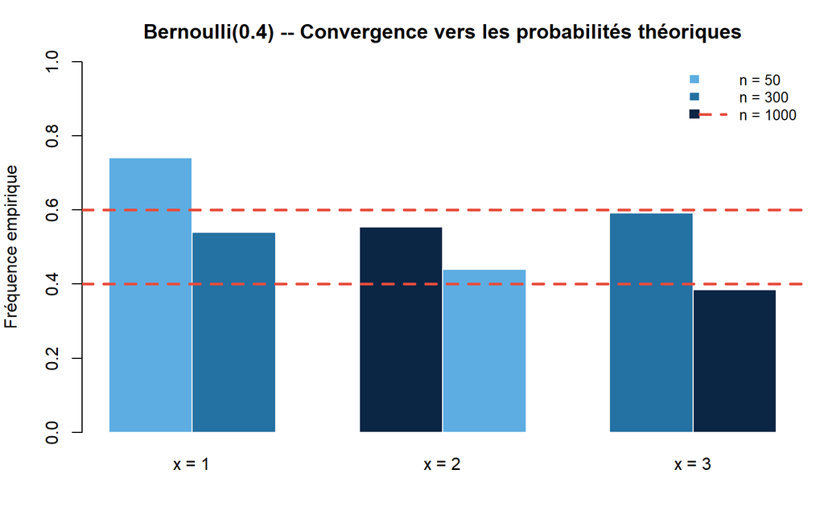

```r
par(mar=c(4,4,3,1))

p_bern <- 0.4

freq_0 <- sapply(TAILLES, function(n) mean(sim_bernoulli(n, p_bern) == 0))
freq_1 <- sapply(TAILLES, function(n) mean(sim_bernoulli(n, p_bern) == 1))

barplot(rbind(freq_0, freq_1), beside=TRUE,
        col=matrix(COULEURS, nrow=2, ncol=length(TAILLES), byrow=FALSE),
        names.arg=paste0("x = ", 1:length(TAILLES)),
        main="Bernoulli(0.4) -- Convergence vers les probabilités théoriques",
        ylab="Fréquence empirique", ylim=c(0,1), border="white")

abline(h=c(1-p_bern, p_bern), col="#E74C3C", lwd=2.5, lty=2)

legend("topright",
       legend=LABELS,
       fill=c(COULEURS, NA),
       border=c(rep("white",2),NA),
       col=c(rep(NA,2),"#E74C3C"),
       lwd=c(NA,NA,2.5),
       lty=c(NA,NA,2),
       bty="n", cex=0.85)
```

### 1.2.2 Binomiale(m, p)

**Definition :** $X \sim \mathcal{B}(m,p)$ = somme de $m$ Bernoulli$(p)$ independantes.
$$E(X) = mp \qquad Var(X) = mp(1-p)$$

**Comment U(0,1) permet la simulation :** On genere $m$ uniformes et compte combien sont $\leq p$. Chaque tirage est une Bernoulli independante – leur somme suit la binomiale.

**Limite :** Necessite $m \times n$ tirages – couteux si $m$ grand. On prefere alors l’approximation normale ($m$ grand) ou Poisson ($mp$ petit).

```r
sim_binomiale <- function(n, m, p) replicate(n, sum(sim_bernoulli(m, p)))
```

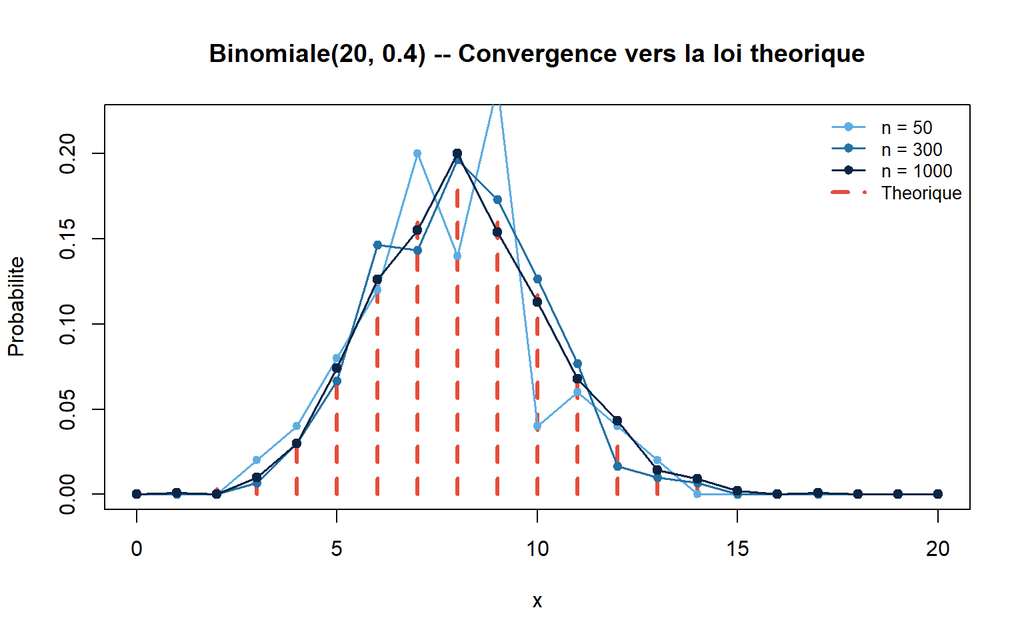

Binomiale(20, 0.4) – Convergence des densites empiriques vers la loi theorique

```r
m_bin <- 20; p_bin <- 0.4; x_vals <- 0:m_bin
plot(x_vals, dbinom(x_vals, m_bin, p_bin), type="h", col="#E74C3C", lwd=3, lty=2,
  main="Binomiale(20, 0.4) -- Convergence vers la loi theorique",
  xlab="x", ylab="Probabilite", ylim=c(0,0.22))
for(i in seq_along(TAILLES)){
  X_i <- sim_binomiale(TAILLES[i], m_bin, p_bin)
  fi  <- table(factor(X_i, levels=x_vals)) / TAILLES[i]
  points(x_vals, as.numeric(fi), col=COULEURS[i], pch=19, cex=0.7+i*0.1)
  lines(x_vals, as.numeric(fi), col=COULEURS[i], lwd=1.5)
}
legend("topright", legend=c(LABELS,"Theorique"),
  col=c(COULEURS,"#E74C3C"), pch=c(19,19,19,NA),
  lwd=c(1.5,1.5,1.5,3), lty=c(1,1,1,2), bty="n", cex=0.85)
```

### 1.2.3 Poisson(lambda)

**Definition :** $X \sim \mathcal{P}(\lambda)$ = nombre d’evenements rares par unite de temps.
$$E(X) = \lambda \qquad Var(X) =
\lambda$$

**Comment U(0,1) permet la simulation (algorithme de Knuth) :** On genere des $U_i$ i.i.d. et on compte $k$ termes avant que $\prod U_i < e^{-\lambda}$. Ce nombre $k-1$ suit exactement $\mathcal{P}(\lambda)$.

**Limite :** Tres lent pour $\lambda > 30$ (nombreuses iterations).

```r
sim_poisson <- function(n, lambda){
  L <- exp(-lambda)
  sapply(1:n, function(i){
    k <- 0; p <- 1
    repeat{ k <- k+1; p <- p*runif(1); if(p <= L) break }
    k - 1
  })
}
```

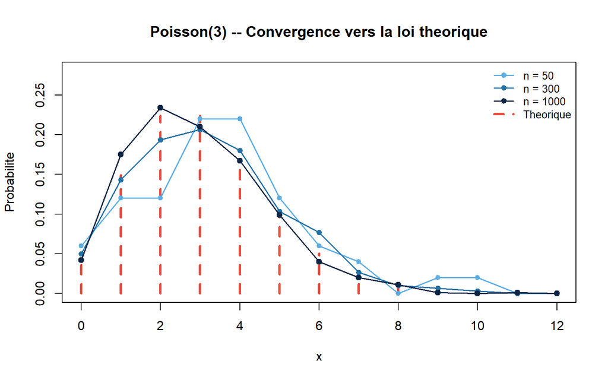

Poisson(3) – Convergence des frequences empiriques vers la loi theorique

```r
lambda <- 3; x_vals <- 0:12
plot(x_vals, dpois(x_vals,lambda), type="h", col="#E74C3C", lwd=3, lty=2,
  main="Poisson(3) -- Convergence vers la loi theorique",
  xlab="x", ylab="Probabilite", ylim=c(0,0.28))
for(i in seq_along(TAILLES)){
  X_i <- sim_poisson(TAILLES[i],lambda)
  fi  <- table(factor(X_i,levels=x_vals))/TAILLES[i]
  points(x_vals, as.numeric(fi), col=COULEURS[i], pch=19, cex=0.7+i*0.1)
  lines(x_vals, as.numeric(fi), col=COULEURS[i], lwd=1.5)
}
legend("topright", legend=c(LABELS,"Theorique"),
  col=c(COULEURS,"#E74C3C"), pch=c(19,19,19,NA),
  lwd=c(1.5,1.5,1.5,3), lty=c(1,1,1,2), bty="n", cex=0.85)
```

### 1.2.4 Geometrique(p)

**Definition :** $X \sim \mathcal{G}(p)$ = nombre d’essais avant le premier succes.
$$E(X) = 1/p \qquad Var(X) = (1-p)/p^2$$

**Comment U(0,1) permet la simulation :** Par inversion : $X = \lceil \ln(U)/\ln(1-p) \rceil$.

**Limite :** Instable si $p \approx 0$ (valeurs simulees tres grandes).

```r
sim_geometrique <- function(n, p) ceiling(log(runif(n)) / log(1-p))
```

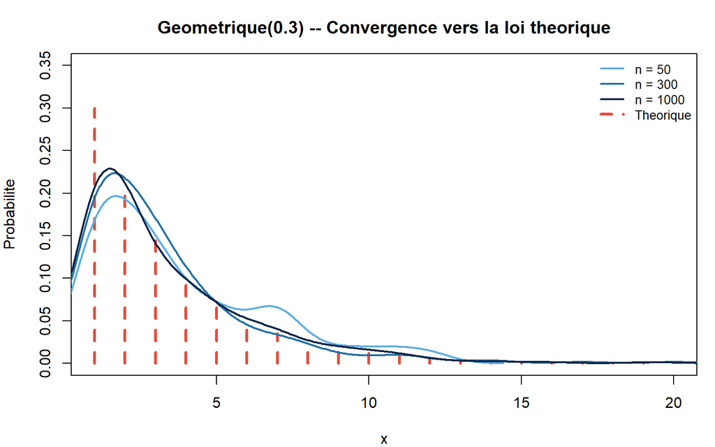

Geometrique(0.3) – Convergence des densites empiriques vers la loi theorique

```r
par(mar=c(4,4,3,1))
p_geo <- 0.3; x_max <- 20; x_vals_geo <- 1:x_max
plot(x_vals_geo, dgeom(x_vals_geo-1, p_geo), type="h", col="#E74C3C", lwd=3, lty=2,
  main="Geometrique(0.3) -- Convergence vers la loi theorique",
  xlab="x", ylab="Probabilite", ylim=c(0,0.35))
for(i in seq_along(TAILLES)){
  X_i <- pmin(sim_geometrique(TAILLES[i], p_geo), x_max)
  lines(density(X_i, bw=0.8), col=COULEURS[i], lwd=2)
}
legend("topright", legend=c(LABELS,"Theorique"),
  col=c(COULEURS,"#E74C3C"), lwd=c(2,2,2,3),
  lty=c(1,1,1,2), bty="n", cex=0.85)
```

## 1.3 Lois Continues

### 1.3.1 Uniforme(a, b)

**Definition :** Toute valeur dans $[a,b]$ est equiprobable.
$$f(x) = 1/(b-a) \qquad E(X) = (a+b)/2 \qquad
Var(X) = (b-a)^2/12$$

**Comment U(0,1) permet la simulation :** Transformation affine directe : $X = a + (b-a) \cdot U$. C’est la brique de base de toutes les autres simulations. Aucune limite.

```r
sim_uniforme <- function(n, a, b) a + (b-a)*runif(n)
```

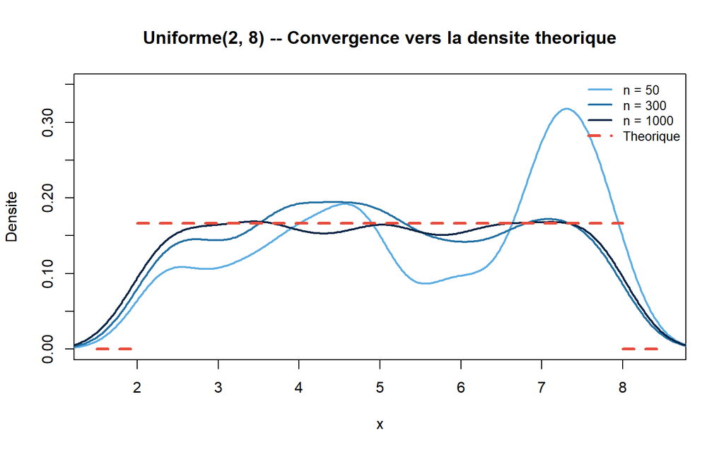

Uniforme(2, 8) – Convergence de la densite empirique vers la densite theorique constante 1/6

```r
a <- 2; b <- 8
plot(NULL, xlim=c(a-0.5,b+0.5), ylim=c(0,0.35),
  main="Uniforme(2, 8) -- Convergence vers la densite theorique",
  xlab="x", ylab="Densite")
for(i in seq_along(TAILLES))
  lines(density(sim_uniforme(TAILLES[i],a,b), bw=0.4), col=COULEURS[i], lwd=2)
segments(a, 1/(b-a), b, 1/(b-a), col="#E74C3C", lwd=3, lty=2)
segments(c(a-0.5,b), c(0,0), c(a,b+0.5), c(0,0), col="#E74C3C", lwd=3, lty=2)
legend("topright", legend=c(LABELS,"Theorique"),
  col=c(COULEURS,"#E74C3C"), lwd=c(2,2,2,3),
  lty=c(1,1,1,2), bty="n", cex=0.85)
```

### 1.3.2 Exponentielle(lambda)

**Definition :** Modelise la duree de vie ou le temps d’attente entre evenements rares.
$$f(x) =
\lambda e^{-\lambda x} \qquad E(X) = 1/\lambda \qquad Var(X) =
1/\lambda^2$$

**Comment U(0,1) permet la simulation :** $F^{-1}(u) = -\ln(1-u)/\lambda$ existe analytiquement. Comme $1-U \sim \mathcal{U}(0,1)$, on simplifie : $X = -\ln(U)/\lambda$. C’est l’exemple canonique de la transformation inverse exacte.

**Limite :** Methode exacte. Legere instabilite numerique pour $U \approx 0$.

```r
sim_exponentielle <- function(n, lambda) -log(runif(n))/lambda
```

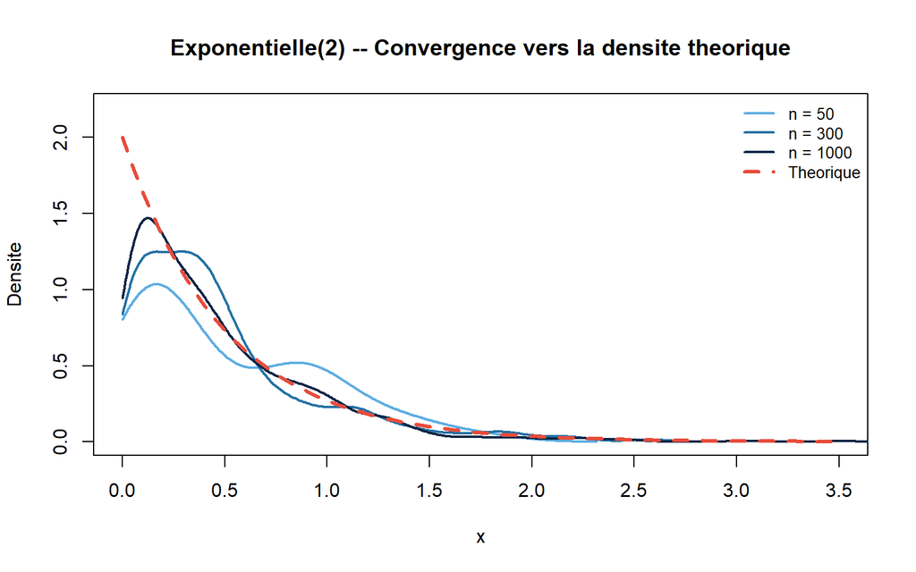

Exponentielle(2) – Convergence de la densite empirique vers la densite theorique

```r
lambda <- 2
plot(NULL, xlim=c(0,3.5), ylim=c(0,2.2),
  main="Exponentielle(2) -- Convergence vers la densite theorique",
  xlab="x", ylab="Densite")
for(i in seq_along(TAILLES))
  lines(density(sim_exponentielle(TAILLES[i],lambda), from=0), col=COULEURS[i], lwd=2)
curve(dexp(x,lambda), add=TRUE, col="#E74C3C", lwd=3, lty=2)
legend("topright", legend=c(LABELS,"Theorique"),
  col=c(COULEURS,"#E74C3C"), lwd=c(2,2,2,3),
  lty=c(1,1,1,2), bty="n", cex=0.85)
```

```r
ks_e <- ks.test(sim_exponentielle(1000,lambda),"pexp",lambda)
cat("Test KS (n=1000) p-valeur:",round(ks_e$p.value,4),
    "->", ifelse(ks_e$p.value>0.05,"H0 non rejetee OK","H0 rejetee"))
```

```
## Test KS (n=1000) p-valeur: 0.8444 -> H0 non rejetee OK
```

### 1.3.3 Normale N(mu, sigma2) – Box-Muller

**Definition :** La loi normale est centrale en statistique.
$$f(x) =
\frac{1}{\sigma\sqrt{2\pi}}\exp\!\left(-\frac{(x-\mu)^2}{2\sigma^2}\right)
\qquad E(X)=\mu \qquad Var(X)=\sigma^2$$

**Comment U(0,1) permet la simulation (Box-Muller) :** $F^{-1}$ **n’existe pas** sous forme analytique pour la normale. Box-Muller utilise deux uniformes independantes $U_1, U_2$ :
$$Z_1 = \sqrt{-2\ln
U_1}\cos(2\pi U_2) \qquad Z_2 = \sqrt{-2\ln U_1}\sin(2\pi U_2)$$
$Z_1$ et $Z_2$ sont deux $\mathcal{N}(0,1)$ independantes, puis $X = \mu + \sigma Z$.

**Limite :** Genere les normales par paires. Legerement plus lent que Ziggurat (utilise dans `rnorm`).

```r
sim_normale <- function(n, mu, sigma2){
  m  <- ceiling(n/2)
  U1 <- runif(m); U2 <- runif(m)
  Z1 <- sqrt(-2*log(U1))*cos(2*pi*U2)
  Z2 <- sqrt(-2*log(U1))*sin(2*pi*U2)
  (mu + sqrt(sigma2)*c(Z1,Z2))[1:n]
}
```

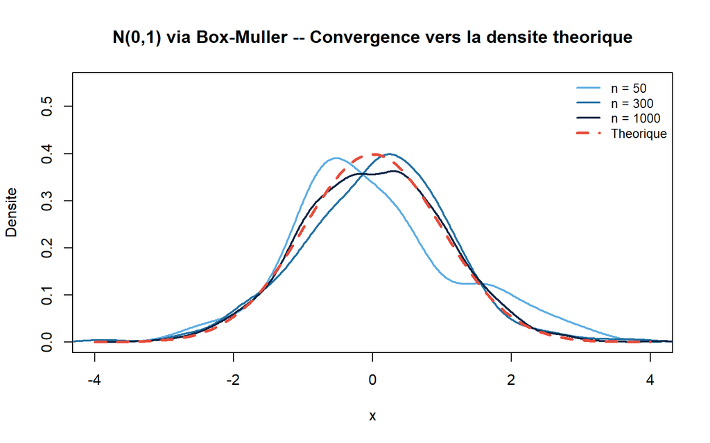

N(0,1) via Box-Muller – Convergence de la densite empirique vers la densite theorique

```r
mu <- 0; sigma2 <- 1
plot(NULL, xlim=c(-4,4), ylim=c(0,0.55),
  main="N(0,1) via Box-Muller -- Convergence vers la densite theorique",
  xlab="x", ylab="Densite")
for(i in seq_along(TAILLES))
  lines(density(sim_normale(TAILLES[i],mu,sigma2)), col=COULEURS[i], lwd=2)
curve(dnorm(x,mu,sqrt(sigma2)), add=TRUE, col="#E74C3C", lwd=3, lty=2)
legend("topright", legend=c(LABELS,"Theorique"),
  col=c(COULEURS,"#E74C3C"), lwd=c(2,2,2,3),
  lty=c(1,1,1,2), bty="n", cex=0.85)
```

```r
ks_n <- ks.test(sim_normale(1000,mu,sigma2),"pnorm",mu,sqrt(sigma2))
cat("Test KS (n=1000) p-valeur:",round(ks_n$p.value,4),
    "->", ifelse(ks_n$p.value>0.05,"H0 non rejetee OK","H0 rejetee"))
```

```
## Test KS (n=1000) p-valeur: 0.0679 -> H0 non rejetee OK
```

### 1.3.4 Gamma(alpha, beta)

**Definition :** Generalise l’exponentielle.
$$E(X) = \alpha/\beta \qquad Var(X) =
\alpha/\beta^2$$

**Comment U(0,1) permet la simulation :** Pour $\alpha$ entier : $X = E_1 + \cdots + E_\alpha$, $E_i \sim \text{Exp}(\beta)$ i.i.d. En developpant : $X = -(1/\beta)\ln(\prod U_i)$.

**Limite :** Valable uniquement pour $\alpha$ **entier**. Marsaglia-Tsang est necessaire pour $\alpha$ non entier.

```r
sim_gamma <- function(n, alpha, beta) replicate(n, sum(sim_exponentielle(alpha, beta)))
```

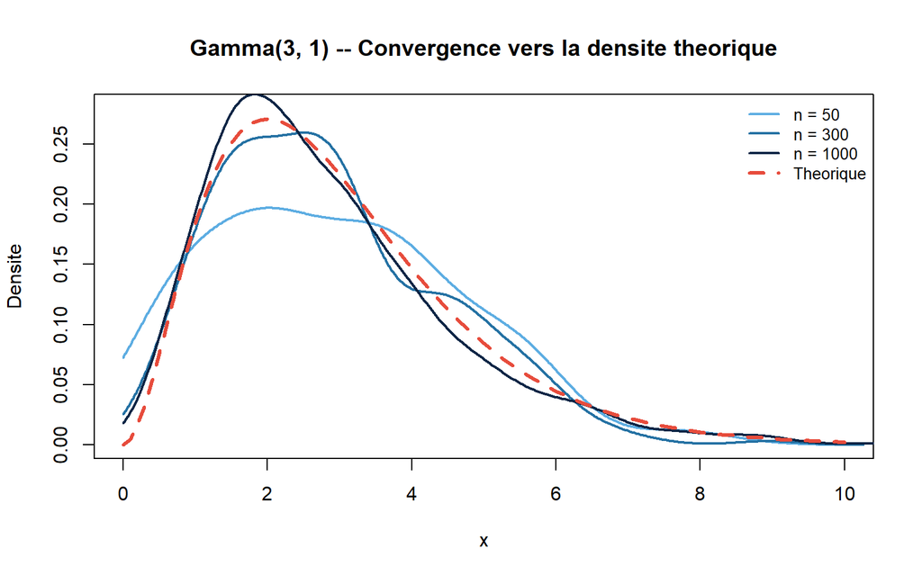

Gamma(3, 1) – Convergence de la densite empirique vers la densite theorique

```r
alpha <- 3; beta <- 1
plot(NULL, xlim=c(0,10), ylim=c(0,0.28),
  main="Gamma(3, 1) -- Convergence vers la densite theorique",
  xlab="x", ylab="Densite")
for(i in seq_along(TAILLES))
  lines(density(sim_gamma(TAILLES[i],alpha,beta), from=0), col=COULEURS[i], lwd=2)
curve(dgamma(x, shape=alpha, rate=beta), add=TRUE, col="#E74C3C", lwd=3, lty=2)
legend("topright", legend=c(LABELS,"Theorique"),
  col=c(COULEURS,"#E74C3C"), lwd=c(2,2,2,3),
  lty=c(1,1,1,2), bty="n", cex=0.85)
```

### 1.3.5 Chi-deux(k)

**Definition :** $X = Z_1^2 + \cdots + Z_k^2$, $Z_i \sim \mathcal{N}(0,1)$ i.i.d.
$$E(X) = k
\qquad Var(X) = 2k$$

**Comment U(0,1) permet la simulation :** Chaine de composition : $U \to Z$ (Box-Muller) $\to Z^2$. Sommer $k$ de ces carres donne le $\chi^2(k)$.

**Limite :** Couteux si $k$ tres grand ($k$ appels Box-Muller par tirage).

```r
sim_chi2 <- function(n, k) replicate(n, sum(sim_normale(k,0,1)^2))
```

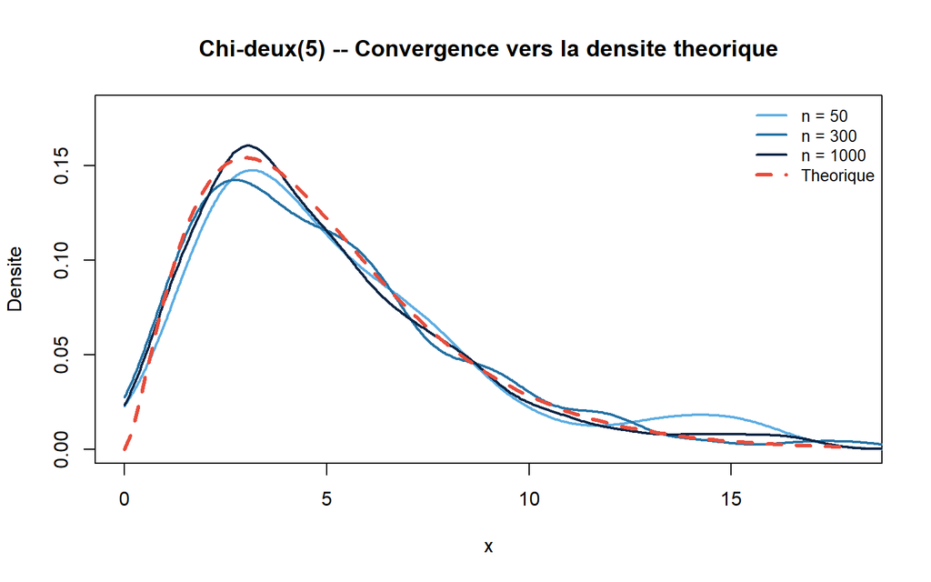

Chi-deux(5) – Convergence de la densite empirique vers la densite theorique

```r
k <- 5
plot(NULL, xlim=c(0,18), ylim=c(0,0.18),
  main="Chi-deux(5) -- Convergence vers la densite theorique",
  xlab="x", ylab="Densite")
for(i in seq_along(TAILLES))
  lines(density(sim_chi2(TAILLES[i],k), from=0), col=COULEURS[i], lwd=2)
curve(dchisq(x,k), add=TRUE, col="#E74C3C", lwd=3, lty=2)
legend("topright", legend=c(LABELS,"Theorique"),
  col=c(COULEURS,"#E74C3C"), lwd=c(2,2,2,3),
  lty=c(1,1,1,2), bty="n", cex=0.85)
```

### 1.3.6 Student(nu)

**Definition :** $T = Z/\sqrt{V/\nu}$, $Z \sim \mathcal{N}(0,1)$, $V \sim \chi^2(\nu)$ independants.
$$E(X) =
0\;(\nu>1) \qquad Var(X) = \nu/(\nu-2)\;(\nu>2)$$

**Comment U(0,1) permet la simulation :** Decomposition structurelle : $U \to Z$ (Box-Muller), $U \to V$ (Chi-deux), ratio $T = Z/\sqrt{V/\nu}$.

**Limite :** Queues epaisses convergent lentement – grand $n$ necessaire pour petit $\nu$.

```r
sim_student <- function(n, nu) sim_normale(n,0,1)/sqrt(sim_chi2(n,nu)/nu)
```

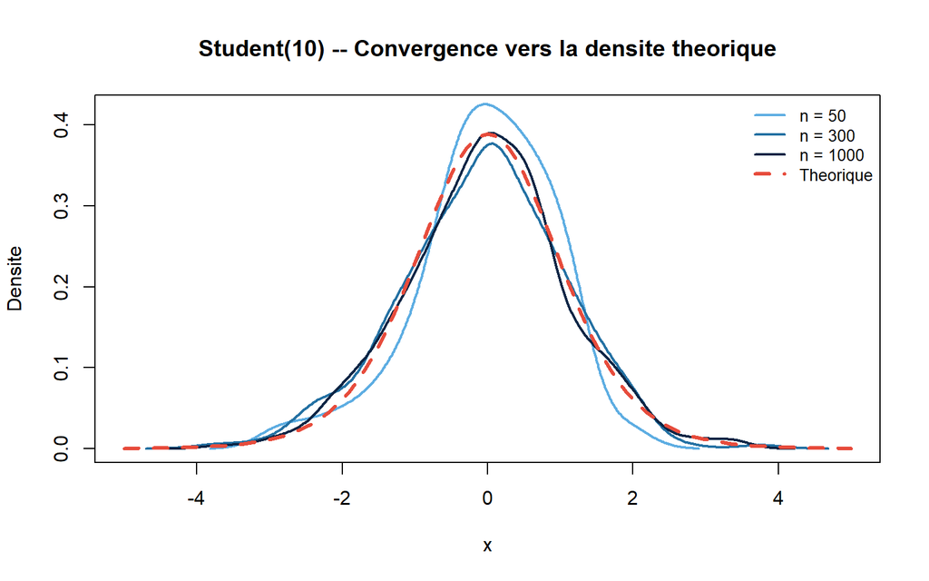

Student(10) – Convergence de la densite empirique vers la densite theorique

```r
nu <- 10
plot(NULL, xlim=c(-5,5), ylim=c(0,0.42),
  main="Student(10) -- Convergence vers la densite theorique",
  xlab="x", ylab="Densite")
for(i in seq_along(TAILLES))
  lines(density(sim_student(TAILLES[i],nu)), col=COULEURS[i], lwd=2)
curve(dt(x,nu), add=TRUE, col="#E74C3C", lwd=3, lty=2)
legend("topright", legend=c(LABELS,"Theorique"),
  col=c(COULEURS,"#E74C3C"), lwd=c(2,2,2,3),
  lty=c(1,1,1,2), bty="n", cex=0.85)
```

### 1.3.7 Fisher(d1, d2)

**Definition :** $F = (V_1/d_1)/(V_2/d_2)$, $V_j \sim \chi^2(d_j)$ independants.
$$E(X) =
d_2/(d_2-2)\;(d_2>2)$$

**Comment U(0,1) permet la simulation :** Chaine complete : $\mathcal{U}(0,1) \to \mathcal{N}(0,1) \to \chi^2 \to \mathcal{F}$.

**Limite :** Queues droites epaisses – necessite grand $n$ pour $d_1$ ou $d_2$ petits.

```r
sim_fisher <- function(n, d1, d2) (sim_chi2(n,d1)/d1)/(sim_chi2(n,d2)/d2)
```

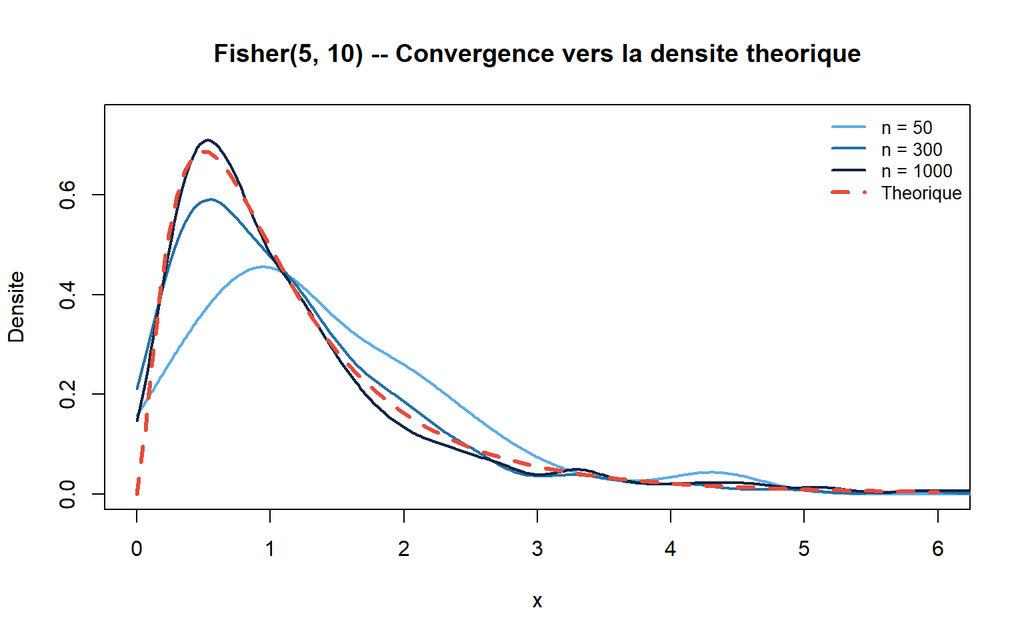

Fisher(5, 10) – Convergence de la densite empirique vers la densite theorique

```r
d1 <- 5; d2 <- 10
plot(NULL, xlim=c(0,6), ylim=c(0,0.75),
  main="Fisher(5, 10) -- Convergence vers la densite theorique",
  xlab="x", ylab="Densite")
for(i in seq_along(TAILLES))
  lines(density(sim_fisher(TAILLES[i],d1,d2), from=0), col=COULEURS[i], lwd=2)
curve(df(x,d1,d2), add=TRUE, col="#E74C3C", lwd=3, lty=2)
legend("topright", legend=c(LABELS,"Theorique"),
  col=c(COULEURS,"#E74C3C"), lwd=c(2,2,2,3),
  lty=c(1,1,1,2), bty="n", cex=0.85)
```

## 1.4 Loi des Grands Nombres – Illustration

La LGN affirme : $P(|\bar{X}_n - \mu| > \varepsilon) \xrightarrow{n\to\infty} 0$ pour tout $\varepsilon > 0$.

### 1.4.1 Convergence de la moyenne empirique

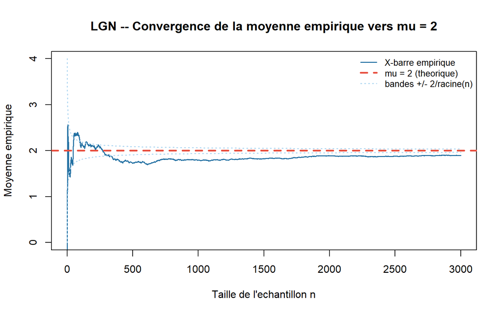

```r
mu_vrai <- 2; sigma2_vrai <- 5; N_max <- 3000
X_grand  <- sim_normale(N_max, mu_vrai, sigma2_vrai)
moyennes <- cumsum(X_grand)/seq_along(X_grand)

plot(1:N_max, moyennes, type="l", col="#2471A3", lwd=1.5,
  main="LGN -- Convergence de la moyenne empirique vers mu = 2",
  xlab="Taille de l'echantillon n", ylab="Moyenne empirique",
  ylim=c(mu_vrai-2, mu_vrai+2))
abline(h=mu_vrai, col="#E74C3C", lwd=2.5, lty=2)
n_s <- 1:N_max
lines(n_s, mu_vrai + 2/sqrt(n_s), col="#AED6F1", lwd=1.5, lty=3)
lines(n_s, mu_vrai - 2/sqrt(n_s), col="#AED6F1", lwd=1.5, lty=3)
legend("topright",
  legend=c("X-barre empirique","mu = 2 (theorique)","bandes +/- 2/racine(n)"),
  col=c("#2471A3","#E74C3C","#AED6F1"),
  lwd=c(1.5,2.5,1.5), lty=c(1,2,3), bty="n", cex=0.85)
```

### 1.4.2 Convergence de la variance empirique

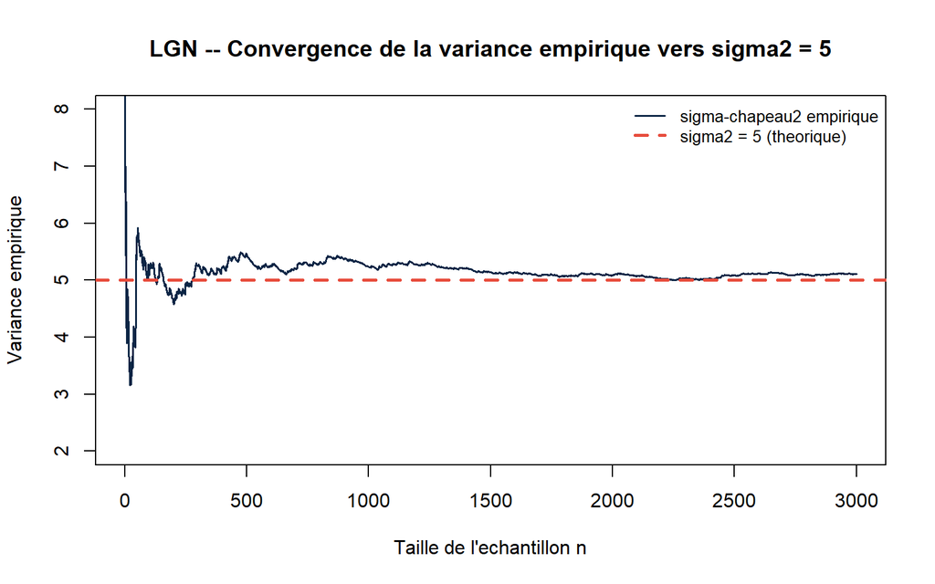

LGN – Convergence de la variance empirique vers sigma2=5 quand n tend vers l’infini

```r
variances <- cumsum((X_grand - mu_vrai)^2)/seq_along(X_grand)

plot(1:N_max, variances, type="l", col="#0B2545", lwd=1.5,
  main="LGN -- Convergence de la variance empirique vers sigma2 = 5",
  xlab="Taille de l'echantillon n", ylab="Variance empirique",
  ylim=c(sigma2_vrai-3, sigma2_vrai+3))
abline(h=sigma2_vrai, col="#E74C3C", lwd=2.5, lty=2)
legend("topright",
  legend=c("sigma-chapeau2 empirique","sigma2 = 5 (theorique)"),
  col=c("#0B2545","#E74C3C"), lwd=c(1.5,2.5), lty=c(1,2), bty="n", cex=0.85)
```

### 1.4.3 Tableau de synthese : methodes, formules et limites

| Loi | Methode | Formule | Limite |
| --- | --- | --- | --- |
| Bernoulli | Inversion | $\mathbf{1}_{U\leq p}$ | Triviale |
| Binomiale | Somme Bernoulli | $\sum_{i=1}^m \mathbf{1}_{U_i\leq p}$ | Lent si $m$ grand |
| Poisson | Knuth | $\prod U_i < e^{-\lambda}$ | Lent si $\lambda>30$ |
| Geometrique | Inversion | $\lceil\ln U/\ln(1-p)\rceil$ | Instable si $p\approx 0$ |
| Uniforme$(a,b)$ | Affine | $a+(b-a)U$ | Aucune |
| Exponentielle | Inversion | $-\ln(U)/\lambda$ | Numerique si $\lambda\gg 1$ |
| Normale | Box-Muller | $\mu+\sigma\sqrt{-2\ln U_1}\cos(2\pi U_2)$ | $F^{-1}$ non analytique |
| Gamma | Somme Exp. | $\sum_{i=1}^\alpha E_i$, $E_i\sim\text{Exp}(\beta)$ | $\alpha$ doit etre entier |
| Chi-deux | Composition | $\sum_{i=1}^k Z_i^2$ | Couteux si $k$ grand |
| Student | Decomposition | $Z/\sqrt{V/\nu}$ | Queues lentes a converger |
| Fisher | Decomposition | $(V_1/d_1)/(V_2/d_2)$ | Idem Student |

> **Conclusion Partie 1 :** La LGN garantit la convergence de toute simulation vers la loi theorique quand $n\to\infty$. En pratique $n=1000$ suffit pour les lois continues classiques. Les lois a queues epaisses (Student petit $\nu$, Fisher) necessitent des $n$ plus grands.

# 2 PARTIE 2 – Simulation de 1000 Observations Gaussiennes N(2, 5)

## 2.1 Generation des donnees

On utilise `sim_normale` construite en Partie 1 avec $\mu=2$ et $\sigma^2=5$.

```r
mu_vrai <- 2; sigma2_vrai <- 5
donnees <- sim_normale(1000, mu_vrai, sigma2_vrai)
data.frame(
  Statistique=c("Taille","Moyenne empirique","Variance empirique"),
  Valeur=c(length(donnees), round(mean(donnees),4), round(var(donnees),4)))
```

| Statistique | Valeur |
| --- | --- |
| Taille | 1000.0000 |
| Moyenne empirique | 2.0795 |
| Variance empirique | 4.6093 |

## 2.2 Visualisation de l’echantillon

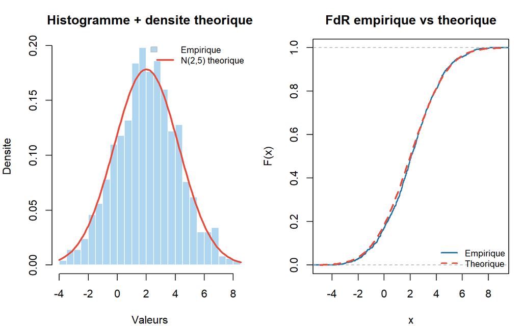

Histogramme et FdR empirique des 1000 observations N(2,5)

```r
par(mfrow=c(1,2), mar=c(4,4,3,1))
hist(donnees, freq=FALSE, breaks=35, col="#AED6F1", border="white",
  main="Histogramme + densite theorique", xlab="Valeurs", ylab="Densite")
curve(dnorm(x,mu_vrai,sqrt(sigma2_vrai)), add=TRUE, col="#E74C3C", lwd=2.5)
legend("topright", legend=c("Empirique","N(2,5) theorique"),
  fill=c("#AED6F1",NA), border=c("grey",NA),
  col=c(NA,"#E74C3C"), lwd=c(NA,2.5), bty="n", cex=0.8)
plot(ecdf(donnees), main="FdR empirique vs theorique",
  xlab="x", ylab="F(x)", col="#2471A3", lwd=2)
curve(pnorm(x,mu_vrai,sqrt(sigma2_vrai)), add=TRUE, col="#E74C3C", lwd=2.5, lty=2)
legend("bottomright", legend=c("Empirique","Theorique"),
  col=c("#2471A3","#E74C3C"), lwd=2, lty=c(1,2), bty="n", cex=0.8)
```

```r
par(mfrow=c(1,1))
```

## 2.3 QQ-Plot de verification

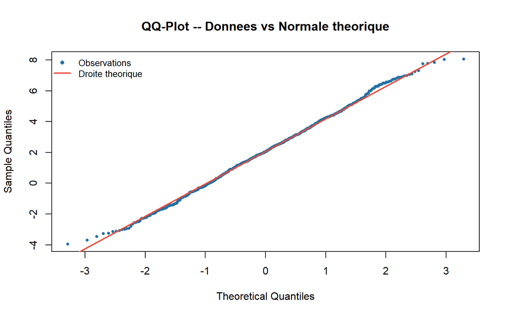

QQ-Plot : alignement des observations sur la droite de la loi normale theorique

```r
qqnorm(donnees, main="QQ-Plot -- Donnees vs Normale theorique",
  col="#2471A3", pch=16, cex=0.6)
qqline(donnees, col="#E74C3C", lwd=2)
legend("topleft", legend=c("Observations","Droite theorique"),
  col=c("#2471A3","#E74C3C"), pch=c(16,NA), lwd=c(NA,2), bty="n", cex=0.85)
```

## 2.4 Resume statistique

```r
data.frame(
  Statistique=c("Minimum","Q1","Mediane","Moyenne","Q3","Maximum",
                "Variance","Ecart-type","Asymetrie","Kurtosis"),
  Valeur=c(round(min(donnees),4), round(quantile(donnees,0.25),4),
    round(median(donnees),4), round(mean(donnees),4),
    round(as.numeric(quantile(donnees,0.75)),4), round(max(donnees),4),
    round(var(donnees),4), round(sd(donnees),4),
    round(skewness(donnees),4), round(kurtosis(donnees),4)))
```

| Statistique | Valeur |
| --- | --- |
| Minimum | -3.9476 |
| Q1 | 0.6506 |
| Mediane | 2.0544 |
| Moyenne | 2.0795 |
| Q3 | 3.4923 |
| Maximum | 8.0598 |
| Variance | 4.6093 |
| Ecart-type | 2.1469 |
| Asymetrie | 0.0092 |
| Kurtosis | 2.8500 |

# 3 PARTIE 3 – Identification du Modele Statistique

## 3.1 Demarche

Explorer $\to$ Formuler des hypotheses $\to$ Estimer $\to$ Valider

## 3.2 Etape 1 – Exploration visuelle

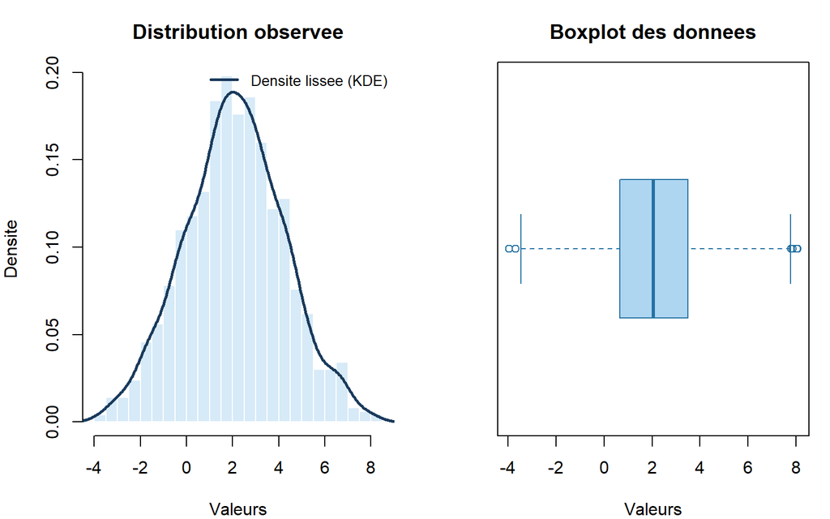

Distribution observee : histogramme avec densite lissee (KDE) et boxplot

```r
par(mfrow=c(1,2), mar=c(4,4,3,1))
hist(donnees, freq=FALSE, breaks=35, col="#D6EAF8", border="white",
  main="Distribution observee", xlab="Valeurs", ylab="Densite")
lines(density(donnees), col="#1A3A5C", lwd=2.5)
legend("topright", legend="Densite lissee (KDE)", col="#1A3A5C", lwd=2.5, bty="n", cex=0.85)
boxplot(donnees, horizontal=TRUE, col="#AED6F1", border="#2471A3",
  main="Boxplot des donnees", xlab="Valeurs")
```

```r
par(mfrow=c(1,1))
```

Observations : distribution unimodale, symetrique, en cloche. **Hypothese : loi normale.**

## 3.3 Etape 2 – Caracterisation statistique

```r
data.frame(
  Indicateur=c("Asymetrie","Kurtosis","Moyenne approx Mediane"),
  Observe=c(round(skewness(donnees),4), round(kurtosis(donnees),4), "Oui"),
  Attendu_N=c("0","3","Oui"))
```

| Indicateur | Observe | Attendu_N |
| --- | --- | --- |
| Asymetrie | 0.0092 | 0 |
| Kurtosis | 2.85 | 3 |
| Moyenne approx Mediane | Oui | Oui |

## 3.4 Etape 3 – Estimation des parametres

```r
mu_MM <- mean(donnees); sigma2_MM <- mean((donnees-mu_MM)^2)
mu_EMV <- mean(donnees); sigma2_EMV <- mean((donnees-mu_EMV)^2)
data.frame(
  Methode=c("Vraie valeur","Methode des moments","EMV"),
  mu=c(mu_vrai, round(mu_MM,4), round(mu_EMV,4)),
  sigma2=c(sigma2_vrai, round(sigma2_MM,4), round(sigma2_EMV,4)))
```

| Methode | mu | sigma2 |
| --- | --- | --- |
| Vraie valeur | 2.0000 | 5.0000 |
| Methode des moments | 2.0795 | 4.6047 |
| EMV | 2.0795 | 4.6047 |

## 3.5 Etape 4 – Validation

```r
ks_res <- ks.test(donnees,"pnorm",mu_EMV,sqrt(sigma2_EMV))
sw_res <- shapiro.test(donnees)
ad_res <- nortest::ad.test(donnees)
data.frame(
  Test=c("Kolmogorov-Smirnov","Shapiro-Wilk","Anderson-Darling"),
  Statistique=c(round(ks_res$statistic,4), round(sw_res$statistic,4), round(ad_res$statistic,4)),
  p_valeur=c(round(ks_res$p.value,4), round(sw_res$p.value,4), round(ad_res$p.value,4)),
  Conclusion=rep("Ne rejette pas H0", 3))
```

|  | Test | Statistique | p_valeur | Conclusion |
| --- | --- | --- | --- | --- |
| D | Kolmogorov-Smirnov | 0.0165 | 0.9473 | Ne rejette pas H0 |
| W | Shapiro-Wilk | 0.9981 | 0.3501 | Ne rejette pas H0 |
| A | Anderson-Darling | 0.2395 | 0.7776 | Ne rejette pas H0 |

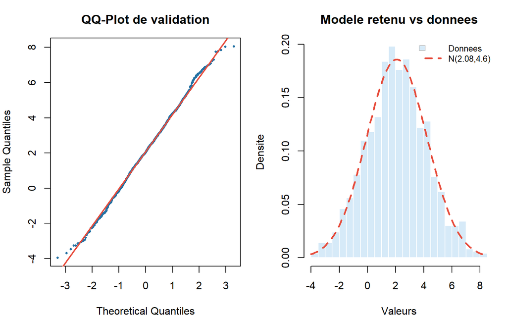

QQ-Plot de validation et superposition du modele retenu sur les donnees

```r
par(mfrow=c(1,2), mar=c(4,4,3,1))
qqnorm(donnees, main="QQ-Plot de validation", col="#2471A3", pch=16, cex=0.5)
qqline(donnees, col="#E74C3C", lwd=2)
hist(donnees, freq=FALSE, breaks=35, col="#D6EAF8", border="white",
  main="Modele retenu vs donnees", xlab="Valeurs", ylab="Densite")
curve(dnorm(x,mu_EMV,sqrt(sigma2_EMV)), add=TRUE, col="#E74C3C", lwd=2.5, lty=2)
legend("topright", legend=c("Donnees",paste0("N(",round(mu_EMV,2),",",round(sigma2_EMV,2),")")),
  fill=c("#D6EAF8",NA), border=c("grey",NA),
  col=c(NA,"#E74C3C"), lwd=c(NA,2.5), lty=c(NA,2), bty="n", cex=0.8)
```

```r
par(mfrow=c(1,1))
```

> **Conclusion finale :** $X \sim \mathcal{N}(\hat{\mu},\hat{\sigma}^2)$ avec $\hat{\mu} = \bar{X}_n$ et $\hat{\sigma}^2 = \frac{1}{n}\sum(X_i-\bar{X}_n)^2$ – correspond bien a $\mu = 2$ et $\sigma^2 = 5$.

# 4 Conclusion Generale

| Partie | Objectif | Outil principal |
| --- | --- | --- |
| **Partie 1** | $\mathcal{U}(0,1)$ engendre toutes les lois + LGN | Transformation inverse, Box-Muller |
| **Partie 2** | Generer $\mathcal{N}(2,5)$ via Box-Muller | `sim_normale` de P1 |
| **Partie 3** | Retrouver le modele sans connaitre la loi | Exploration, EMV, tests |

$$\underbrace{\text{Simuler}}_{\text{P1}}
\;\to\; \underbrace{\text{Avoir des donnees}}_{\text{P2}} \;\to\;
\underbrace{\text{Inferer}}_{\text{P3}}$$

*Universite Alioune Diop de Bambey – Master 1 SID – Probabilites et Integration 1 – Responsable : I. FAYE*